# AP-4209 ESIEE-Paris: 2023 -2024

Fouille de données avec R pour la data science et l’intelligence artificielle

Projet 3 : Classification bayésienne et analyse factorielle discriminante

Eliott Vigier et Alexandre Wu – ESIEE Paris

**Résumé :** Le jeu de données contient des informations sur les thèses de doctorat françaises, en mettant l’accent sur la similarité sémantique. Cela représente un défi unique pour la classification en raison de la nature textuelle et sémantique des données.

**Objectif principal :** Mettre en place une classification bayésienne avancée avec analyse discriminante sur un jeu de données de résumés de thèses de doctorat françaises afin de les catégoriser en domaines d’étude.

**Source des données :** Recherche de similarité sémantique de thèse de doctorat française à partir de Kaggle.

- **Lien :** https://www.kaggle.com/code/antoinebourgois2/french-doctoral-thesissemantic-similarity-search

### 1 Introduction

Dans ce projet, nous allons cherché à prédire le domaine d’une thèse en fonction de sa descritpion. Après le chargement et l’exploration initiale des données, nous procédons au prétraitement pour préparer les données à l’analyse. Nous appliquerons ensuite l’Analyse Discriminante Linéaire (LDA) pour la réduction de dimensionnalité et la classification, suivie d’une évaluation rigoureuse de la performance du modèle à travers diverses métriques. On observera aussi un modèle bayésien naif. Pour optimiser les hyperparamètres, nous implémenterons une grid search, et finalement, nous validerons la robustesse de notre modèle à l’aide de techniques de validation croisée.

#### 1.1 Programmation

Nous utilisons :

- `dplyr` : Manipulation de données avec des fonctions intuitives.
- `plotly` : Création de graphiques interactifs.
- `tidyverse` : Collection de packages pour la science des données (inclut `dplyr`, `ggplot2`, etc.).
- `stringr` : Manipulation de chaînes de caractères.
- `tm` : Gestion et traitement de textes pour l’analyse de contenu.
- `kableExtra` : [Génération de tableaux améliorés](https://cran.r-project.org/web/packages/kableExtra/vignettes/awesome_table_in_html.html) en HTML ou PDF.
- `knitr` : Intégration de code R dans des documents LaTeX, HTML, Markdown.
- `text2vec` : Traitement de texte et modélisation vectorielle.
- `tokenizers` : Tokenisation et stemming du texte pour l’analyse.
- `tidytext` : Traitement de texte dans le cadre du tidyverse.
- `caret` : Séparation des données ici.
- `MASS` : Utilisation pour l’AFD (lda).
- `e1071` : Fonctions pour l’apprentissage statistique, y compris la classification bayésienne.

Nous avons également utilisé Chat GPT comme aide à se projet.

### 2 Chargement et exploration des données

##### 2.1 Chargez le jeu de données dans R

On commence à charger les librairies nécessaires pour le projet :

```r
library(dplyr)
```

```r
library(plotly)
library(tidyverse)
library(stringr)
library(tm)
library(kableExtra)
library(knitr)
library(text2vec)
library(tokenizers)
library(tidytext)
library(caret)
library(MASS)
library(e1071)
```

Ensuite on charge le dataset :

```r
# Chargement des jeux de données
df  <- read.csv("french_thesis_20231021_metadata.csv")
```

Affichage du tableau avec *kableExtra* des deux jeux données

```r
head(df,3) %>%
  kbl(digits=3) %>%
  kable_styling(bootstrap_options = "striped", full_width = F, position = "center", latex_options = 'stripped') %>% scroll_box( height = "250px")
```

| URL | Title | Author | Description | Direction | Domain | Statuts | Date |
| --- | --- | --- | --- | --- | --- | --- | --- |
| 1971PAUU3003 | Noyaux salins hygroscopiques et sursaturation saline | Anne-Marie Delage |  | [(‘Camille Lafargue’, ‘067206956’)] | Physique. Thermodynamique | Soutenue | 1971-01-01 |
| 1972PAUU3002 | Contribution à l’étude de l’évolution des propriétés diélectriques d’échantillons obtenus par solidification de solutions aqueuses de chlorure d’ammonium | René Cazaban-Marque |  | [(‘Camille Lafargue’, ‘067206956’)] | Physique. Thermodynamique | Soutenue | 1972-01-01 |
| 1973NAN10113 | Lymphocytologie | Domagoj Sabolović | “La lymphocytologie est une discipline de l’immunologie générale. Elle a débuté par la découverte du rôle fondamental du petit lymphocyte dans l’immunité. Son développement a été accéléré par la mise … | [(’ Directeur de thèse inconnu’, None)] | Sciences naturelles | Soutenue | 1973-01-01 |

On affiche seulement les 3 premières lignes comme le jeu de données est volumineux Voici sa shape.

```r
dim(df)
```

```
## [1] 519578      8
```

##### 2.2 Analyse exploratoire des données (EDA) pour comprendre la distribution des classes

On cherche les différents domaines de thèse du dataset.

```r
# Type de domaines
type_Domain<-unique(df$Domain)
num_type_Domain<- length(type_Domain)
num_type_Domain
```

```
## [1] 27456
```

On a alors 27 456 différents domaines de thèse.

On observe la distribution des différents domaines du jeu de données. Comme il y a 27 456 différents types, on va se concentrer sur les 10 premiers. Ici on affiche les 15 premiers afin d’observer les domaines et savoir si aucun ne se repète.

```r
# Création du tableau de distribution
domain_distribution <- table(df$Domain)
# Tri du tableau de distribution de manière décroissante
domain_distribution_sorted_desc <- sort(domain_distribution, decreasing = TRUE)
# Affichage du tableau trié de manière décroissante
head(domain_distribution_sorted_desc,15)
```

```
##
##                                                      Médecine
##                                                         22955
##                                                  Informatique
##                                                         18168
##                                                      Physique
##                                                         18057
##                                                        Chimie
##                                                         12662
##                                          Sciences économiques
##                                                         10452
##                                                      Histoire
##                                                          9894
## Sciences biologiques et fondamentales appliquées. Psychologie
##                                                          8795
##                                           Sciences appliquées
##                                                          8774
##                                           Sciences de gestion
##                                                          7951
##                                                   Psychologie
##                                                          7445
##                                                    Sociologie
##                                                          7019
##                                                  Droit public
##                                                          6782
##                                                     Pharmacie
##                                                          6671
##                                                   Droit privé
##                                                          6134
##                                                 Mathématiques
##                                                          6002
```

On observe alors une répartion assez inégale. On voit par exemple que le domaine “Médecine” a presque 3 fois plus de thèses que le domaine “Droit public”. De plus, on remarque que la “Psychologie” et les “Sciences appliquées” se répètent entre différentes classes (“Sciences biologiques et fondamentales appliquées. Psychologie”). Ainsi on les supprime et prend les deux suivantes : “Sociologie” et “Droit public”. (Raisonnement avec Joshua Dumont)

### 3 Prétraitement des données

#### 3.1 Réduction du dataframe

```r
# Extraire les 12 premiers domaines
top_12_domains <- names(domain_distribution_sorted_desc)[1:12]

# Filtrer df pour garder seulement les lignes correspondant aux 12 premiers domaines
df_reduit <- df[df$Domain %in% top_12_domains, ]

# Enlever les lignes où la colonne 'Domain' contient 'Sciences appliquées' ou 'Psychologie'
df_reduit <- df_reduit[!(df_reduit$Domain %in% c("Sciences appliquées", "Psychologie")), ]
```

Voici le résultat pour les 3 premières lignes.

```r
# Affichage
head(df_reduit,3) %>%
  kbl(digits=3) %>%
  kable_styling(bootstrap_options = "striped", full_width = F, position = "center", latex_options = 'stripped') %>% scroll_box( height = "250px")
```

|  | URL | Title | Author | Description | Direction | Domain | Statuts | Date |
| --- | --- | --- | --- | --- | --- | --- | --- | --- |
| 5 | s66414 | Le personnel diplomatique francais sous la revolution de 1789 a 1799. | Henri Robert |  | [(‘Jean Tulard’, ‘027171183’)] | Histoire | En préparation | 1976-12-01 |
| 6 | 1993PA100148 | Les miracles de l’Évêque Jean Michel et le culte des saints dans le Diocèse d’Angers v. 1370- v. 1560 | Jean-Michel Matz |  | [(‘André Vauchez’, ‘027178501’)] | Histoire | Soutenue | 1979-01-01 |
| 10 | s66309 | Le problème du contrôle de l’administration économique. | Angelos Marcopoulos |  | [(‘Jean Waline’, ‘033748152’)] | Droit public | En préparation | 1980-04-01 |

On peut regarder les dimennsions de notre jeu de données.

```r
dim(df_reduit)
```

```
## [1] 122735      8
```

On va maintenant se charger d’enlever les données vides et les données manquantes de la colonne “Description”. Cette dernière nous permettra ensuite de prédire le “Domain”.

Texte vide :

```r
# Supprimer les lignes où la colonne 'Description' ne contient pas de texte
df_reduit_clean <- df_reduit[df_reduit$Description != "" & nzchar(trimws(df_reduit$Description)), ]
# Taille des données
dim(df_reduit_clean)
```

```
## [1] 86771     8
```

On a alors perdu preque 40 000 lignes.

```r
# Enlever les lignes avec des valeurs NA dans la colonne 'Description'
df_reduit_clean <- df_reduit_clean[!is.na(df_reduit_clean$Description), ]
# Taille des données
dim(df_reduit_clean)
```

```
## [1] 86771     8
```

0 données manquantes.

On va observer notre distribution.

```r
# Création du tableau de distribution
domain_distribution_reduit <- table(df_reduit_clean$Domain)
domain_distribution_reduit
```

```
##
##                                                        Chimie
##                                                         10519
##                                                  Droit public
##                                                          5998
##                                                      Histoire
##                                                          7447
##                                                  Informatique
##                                                         15987
##                                                      Médecine
##                                                           436
##                                                      Physique
##                                                         16232
## Sciences biologiques et fondamentales appliquées. Psychologie
##                                                          8044
##                                           Sciences de gestion
##                                                          6635
##                                          Sciences économiques
##                                                          9375
##                                                    Sociologie
##                                                          6098
```

On constate alors que étonnament, la classe “Médecine” qui comportait le plus de thèses (22 955), est celle qui en comporte le moins maintenant dans ces 10 Classes (436). Ainsi beaucoup d’entre-elles étaient vides.

Interprétation graphique.

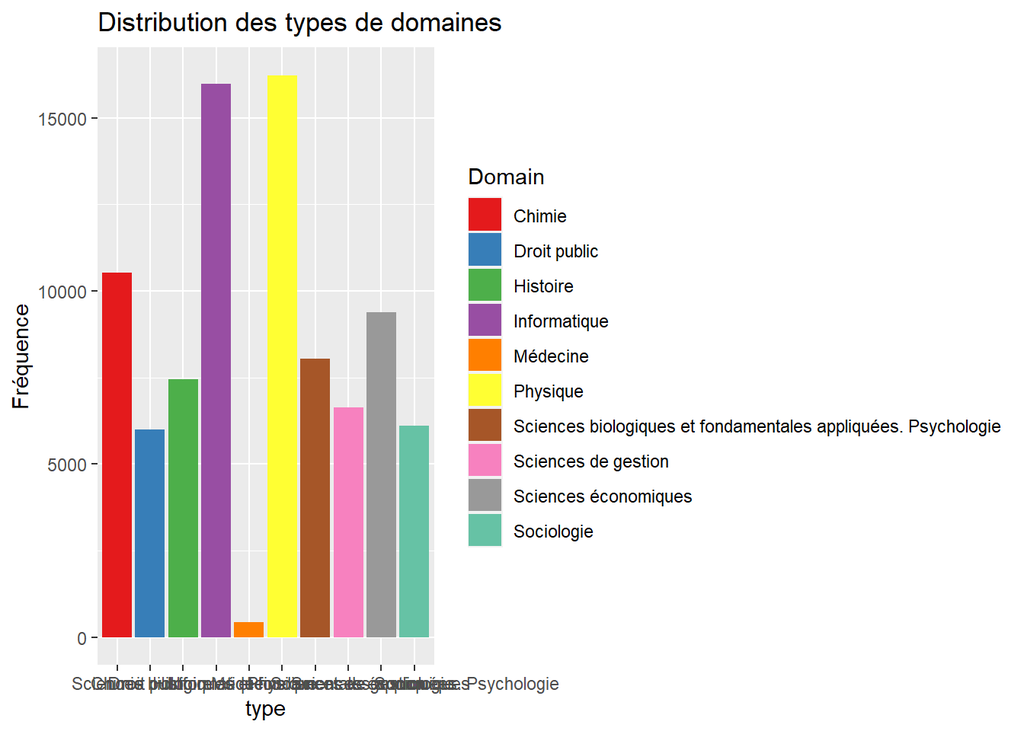

```r
# Définition une palette personnalisée de 10 couleurs
my_colors <- c("#e41a1c", "#377eb8", "#4daf4a", "#984ea3", "#ff7f00", "#ffff33", "#a65628", "#f781bf", "#999999", "#66c2a5")

ggplot(df_reduit_clean, aes(x=Domain, fill = Domain)) +
      geom_bar() +
      scale_fill_manual(values=my_colors) +
      xlab("type") +
      ylab("Fréquence") +
      ggtitle("Distribution des types de domaines")
```

Les descriptions sont assez volumineuses comparées aux projets précédents, ainsi il va falloir encore plus réduire que d’habitude les données. On garde en indice les numéros de lignes au cas où on en aurait besoin plus tard.

```r
# Ajoute une colonne 'Indice' avec une séquence allant de 1 au nombre de lignes.
df_reduit_clean$Indice <- 1:nrow(df_reduit_clean)

# Affichage
head(df_reduit,3) %>%
  kbl(digits=3) %>%
  kable_styling(bootstrap_options = "striped", full_width = F, position = "center", latex_options = 'stripped') %>% scroll_box( height = "250px")
```

|  | URL | Title | Author | Description | Direction | Domain | Statuts | Date |
| --- | --- | --- | --- | --- | --- | --- | --- | --- |
| 5 | s66414 | Le personnel diplomatique francais sous la revolution de 1789 a 1799. | Henri Robert |  | [(‘Jean Tulard’, ‘027171183’)] | Histoire | En préparation | 1976-12-01 |
| 6 | 1993PA100148 | Les miracles de l’Évêque Jean Michel et le culte des saints dans le Diocèse d’Angers v. 1370- v. 1560 | Jean-Michel Matz |  | [(‘André Vauchez’, ‘027178501’)] | Histoire | Soutenue | 1979-01-01 |
| 10 | s66309 | Le problème du contrôle de l’administration économique. | Angelos Marcopoulos |  | [(‘Jean Waline’, ‘033748152’)] | Droit public | En préparation | 1980-04-01 |

Maintenant on va vouloir entraîner le modèle. Cependant il faut faire pour ceci un prétraitement des données. On a 10 classes très mals réparties, on va donc les ré-équilibrées. On prend 110 données de chaque classes. Ce dataset servira à l’entrainement (80 %) et au test (20 %). On prend 110 données de chaque classes car c’est proche de la limite de lda. Par exemple pour 120 par classes on obtenait ‘error stack overflow’.

```r
# Initialise le dataframe equilibre vide
df_equilibre_reduit <- data.frame()

# Liste des domaines uniques
domaines <- unique(df_reduit_clean$Domain)

# Itérer sur chaque domaine
for (domaine in domaines) {
  # Sélectionner les lignes du domaine courant
  sous_ensemble <- df_reduit_clean[df_reduit_clean$Domain == domaine, ]

  # Vérifie si le nombre de lignes dépasse 110
  if (nrow(sous_ensemble) > 110) {
    # Réduis aléatoirement à 110 lignes
    set.seed(123) # Pour la reproductibilité
    indices <- sample(nrow(sous_ensemble), 110)
    sous_ensemble <- sous_ensemble[indices, ]
  }

  # Ajoute le sous-ensemble réduit au dataframe equilibre
  df_equilibre_reduit <- rbind(df_equilibre_reduit, sous_ensemble)
}


# Vérification des dimensions du dataframe equilibre
dim(df_equilibre_reduit)
```

```
## [1] 1100    9
```

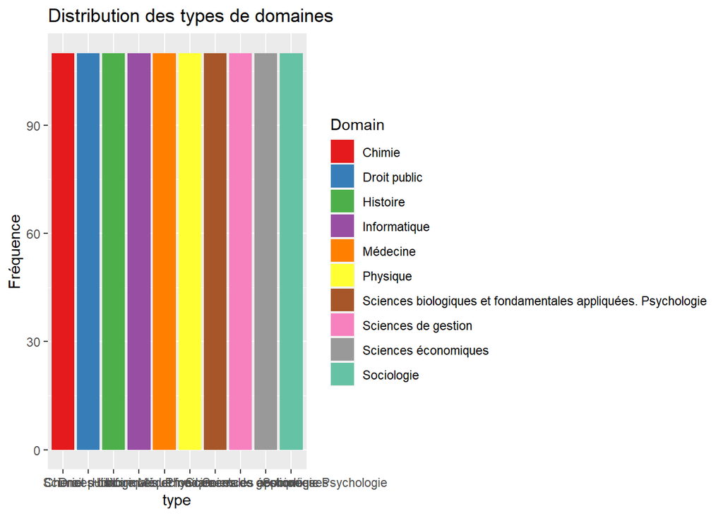

```r
# Définition une palette personnalisée de 10 couleurs
my_colors <- c("#e41a1c", "#377eb8", "#4daf4a", "#984ea3", "#ff7f00", "#ffff33", "#a65628", "#f781bf", "#999999", "#66c2a5")

ggplot(df_equilibre_reduit, aes(x=Domain, fill = Domain)) +
      geom_bar() +
      scale_fill_manual(values=my_colors) +
      xlab("type") +
      ylab("Fréquence") +
      ggtitle("Distribution des types de domaines")
```

#### 3.2 Nettoyage les données textuelles en supprimant les caractères spéciaux, la ponctuation et les mots vides

Maintenant, on peut nétoyer toutes les données de ce jeu de données.

```r
# Étape 1: Supprimer la ponctuation

df_equilibre_reduit$Description_clean <- sapply(df_equilibre_reduit$Description, removePunctuation)

# Étape 2: Convertir en minuscules et supprimer les stop words

# Mettre en miniscule
df_equilibre_reduit$Description_clean <- sapply(df_equilibre_reduit$Description_clean, tolower)
# Supprimer les mots vides
df_equilibre_reduit$Description_clean <- sapply(df_equilibre_reduit$Description_clean, function(x) removeWords(x, stopwords("fr")))
```

```r
# Affichage
head(df_equilibre_reduit,3) %>%
  kbl(digits=3) %>%
  kable_styling(bootstrap_options = "striped", full_width = F, position = "center", latex_options = 'stripped') %>% scroll_box( height = "250px")
```

|  | URL | Title | Author | Description | Direction | Domain | Statuts | Date | Indice | Description_clean |
| --- | --- | --- | --- | --- | --- | --- | --- | --- | --- | --- |
| 60509 | 1991PA112324 | Etude microstructurale fine de revetements ceramiques de type barriere thermique; incidents sur la resistance thermomecanique de ces revetements | Laurent Lelait | Dans cette etude la structure de revetements de type barriere thermique en zircone-yttriee a ete etudiee a une echelle microscopique fine. Il a ete montre que certains depots de zircone stabilisee par… | [(‘Patrick Veyssière’, ‘076552039’)] | Physique | Soutenue | 1991-01-01 | 10784 | etude structure revetements type barriere thermique zirconeyttriee a ete etudiee a echelle microscopique fine a ete montre certains depots zircone stabilisee 8 dyttrine presentent divers types defauts… |
| 61554 | 1991PAUU3011 | Cinétique réactionnelle en régime hydrodynamique dans l’oxygène : application à la production industrielle de l’ozone | Sahraoui Hadj-Ziane | La simulation numérique de la production d’ozone par des décharges couronne positives pointe-plan et fil-cylindre dans l’oxygène pur nous a conduit d’une part à étudier la cinétique chimique des espèc… | [(‘Bernard Held’, ‘030889294’)] | Physique | Soutenue | 1991-01-01 | 10999 | simulation numérique production dozone décharges couronne positives pointeplan filcylindre loxygène pur a conduit dune part étudier cinétique chimique espèces neutres doxygène atomique moléculaire doz… |
| 280420 | 2010STRA6181 | Etude théorique du lien entre structure électronique locale et environnement structural et chimique dans les alliages et couches minces à base de métaux de transition : application au système CoAu | Ali Jaafar | Ce travail de thèse a consisté à caractériser théoriquement la structure atomique de surfaces pures (substrats) nanostructurées ou non et de dépôts métalliques (hétéro-épitaxiés) sur ces surfaces. Not… | [(‘Christine Goyhenex’, ‘081992904’)] | Physique | Soutenue | 2010-01-01 | 52083 | travail thèse a consisté caractériser théoriquement structure atomique surfaces pures substrats nanostructurées non dépôts métalliques hétéroépitaxiés surfaces étude sest articulée autour trois axes p… |

On va labéliser les classes et les numéroter de 1 à 10.

```r
# Convertir les étiquettes des domaines en entiers
domaines_type<- unique(df_equilibre_reduit$Domain)
# Utilise les types de domaines uniques comme niveaux dans la conversion de facteurs
df_equilibre_reduit <- df_equilibre_reduit %>%
  mutate(domain_numeric = as.integer(factor(Domain, levels = domaines_type))-1)
```

```r
# Affichage
head(df_equilibre_reduit,3) %>%
  kbl(digits=3) %>%
  kable_styling(bootstrap_options = "striped", full_width = F, position = "center", latex_options = 'stripped') %>% scroll_box( height = "250px")
```

|  | URL | Title | Author | Description | Direction | Domain | Statuts | Date | Indice | Description_clean | domain_numeric |
| --- | --- | --- | --- | --- | --- | --- | --- | --- | --- | --- | --- |
| 60509 | 1991PA112324 | Etude microstructurale fine de revetements ceramiques de type barriere thermique; incidents sur la resistance thermomecanique de ces revetements | Laurent Lelait | Dans cette etude la structure de revetements de type barriere thermique en zircone-yttriee a ete etudiee a une echelle microscopique fine. Il a ete montre que certains depots de zircone stabilisee par… | [(‘Patrick Veyssière’, ‘076552039’)] | Physique | Soutenue | 1991-01-01 | 10784 | etude structure revetements type barriere thermique zirconeyttriee a ete etudiee a echelle microscopique fine a ete montre certains depots zircone stabilisee 8 dyttrine presentent divers types defauts… | 0 |
| 61554 | 1991PAUU3011 | Cinétique réactionnelle en régime hydrodynamique dans l’oxygène : application à la production industrielle de l’ozone | Sahraoui Hadj-Ziane | La simulation numérique de la production d’ozone par des décharges couronne positives pointe-plan et fil-cylindre dans l’oxygène pur nous a conduit d’une part à étudier la cinétique chimique des espèc… | [(‘Bernard Held’, ‘030889294’)] | Physique | Soutenue | 1991-01-01 | 10999 | simulation numérique production dozone décharges couronne positives pointeplan filcylindre loxygène pur a conduit dune part étudier cinétique chimique espèces neutres doxygène atomique moléculaire doz… | 0 |
| 280420 | 2010STRA6181 | Etude théorique du lien entre structure électronique locale et environnement structural et chimique dans les alliages et couches minces à base de métaux de transition : application au système CoAu | Ali Jaafar | Ce travail de thèse a consisté à caractériser théoriquement la structure atomique de surfaces pures (substrats) nanostructurées ou non et de dépôts métalliques (hétéro-épitaxiés) sur ces surfaces. Not… | [(‘Christine Goyhenex’, ‘081992904’)] | Physique | Soutenue | 2010-01-01 | 52083 | travail thèse a consisté caractériser théoriquement structure atomique surfaces pures substrats nanostructurées non dépôts métalliques hétéroépitaxiés surfaces étude sest articulée autour trois axes p… | 0 |

#### 3.3 Tokenisation et stemming

On peut maintenant tokenizer et stemmiser le texte.

```r
# Applique la tokenization et le stemming avec la fonction tokenize_word_stems
df_equilibre_reduit$Description_clean<- sapply(df_equilibre_reduit$Description_clean, function(phrase){
    tokenize_word_stems(phrase,language = "french")
  })

# On met des espaces entre les mots au lieu de ','
df_equilibre_reduit$Description_clean <- sapply(df_equilibre_reduit$Description_clean, paste, collapse = " ")
```

```r
# Affichage
head(df_equilibre_reduit,1) %>%
  kbl(digits=3) %>%
  kable_styling(bootstrap_options = "striped", full_width = F, position = "center", latex_options = 'stripped') %>% scroll_box( height = "250px")
```

|  | URL | Title | Author | Description | Direction | Domain | Statuts | Date | Indice | Description_clean | domain_numeric |
| --- | --- | --- | --- | --- | --- | --- | --- | --- | --- | --- | --- |
| 60509 | 1991PA112324 | Etude microstructurale fine de revetements ceramiques de type barriere thermique; incidents sur la resistance thermomecanique de ces revetements | Laurent Lelait | Dans cette etude la structure de revetements de type barriere thermique en zircone-yttriee a ete etudiee a une echelle microscopique fine. Il a ete montre que certains depots de zircone stabilisee par… | [(‘Patrick Veyssière’, ‘076552039’)] | Physique | Soutenue | 1991-01-01 | 10784 | etud structur revet typ barrier thermiqu zirconeyttrie a ete etudie a echel microscop fin a ete montr certain depot zircon stabilise 8 dyttrin presentent diver typ defaut maclag pseudoapb mem lapparit… | 0 |

#### 3.4 TF-IDF

##### 3.4.1 Séparation de l’entrainement et du test du dataset

Nos données sont maintenant prêtes pour une TF-IDF avant l’entrainement. Pour ceci séparons les en 80 % d’entrainment et 20 % de test.

```r
set.seed(123) # pour une reproduction cohérente des résultats
Index <- createDataPartition(df_equilibre_reduit$domain_numeric, p = 0.8, list = FALSE)
train <- df_equilibre_reduit[Index,]
test <- df_equilibre_reduit[-Index,]

print(dim(train))
```

```
## [1] 880  11
```

```r
print(dim(test))
```

```
## [1] 220  11
```

##### 3.4.2 Calcul TF-IDF

Faisons la TF-IDF des données d’entrainement puis de test.

Pour l’entrainement.

```r
# TF-IDF
# Étape 1: Création d'un corpus
corpus_train <- VCorpus(VectorSource(train$Description_clean))
# Étape 2: Création d'une DTM et application de la TF-IDF
dtm_train <- DocumentTermMatrix(corpus_train, control = list(weighting = weightTfIdf))

# Sauvegarde du vocabulaire pour le jeu d'entraînement
dict_train <- Terms(dtm_train)

# Convertir en dataframe
tf_idf_train_dataframe <- as.data.frame(as.matrix(dtm_train))
```

```r
# Affichage des 5 premières et dernières colonnes
head(tf_idf_train_dataframe[, c(1:5, (ncol(tf_idf_train_dataframe)-4):ncol(tf_idf_train_dataframe))], 6)%>%
  kbl(digits=3) %>%
  kable_styling(bootstrap_options = "striped", full_width = F, position = "center", latex_options = 'stripped')
```

| µct | 000 | 000001 | 00003 | 0001 | βcd | γfe2o3 | λcalcul | μgl | φr1 |
| --- | --- | --- | --- | --- | --- | --- | --- | --- | --- |
| 0 | 0 | 0 | 0 | 0 | 0 | 0 | 0 | 0 | 0 |
| 0 | 0 | 0 | 0 | 0 | 0 | 0 | 0 | 0 | 0 |
| 0 | 0 | 0 | 0 | 0 | 0 | 0 | 0 | 0 | 0 |
| 0 | 0 | 0 | 0 | 0 | 0 | 0 | 0 | 0 | 0 |
| 0 | 0 | 0 | 0 | 0 | 0 | 0 | 0 | 0 | 0 |
| 0 | 0 | 0 | 0 | 0 | 0 | 0 | 0 | 0 | 0 |

Pour le test.

```r
# TF-IDF
# Étape 1: Création d'un corpus
corpus_test <- VCorpus(VectorSource(test$Description_clean))
# Étape 2: Création d'une DTM et application de la TF-IDF avec le dictionnaire
dtm_test <- DocumentTermMatrix(corpus_test, control = list(weighting = weightTfIdf, dictionary = dict_train))
```

[output not shown]

[output cut: 52 more lines]

[output not shown]

```r
# Convertir en dataframe
tf_idf_test_dataframe <- as.data.frame(as.matrix(dtm_test))
```

```r
# Affichage des 5 premières et dernières colonnes
head(tf_idf_test_dataframe[, c(1:5, (ncol(tf_idf_test_dataframe)-4):ncol(tf_idf_test_dataframe))], 6)%>%
  kbl(digits=3) %>%
  kable_styling(bootstrap_options = "striped", full_width = F, position = "center", latex_options = 'stripped')
```

| µct | 000 | 000001 | 00003 | 0001 | βcd | γfe2o3 | λcalcul | μgl | φr1 |
| --- | --- | --- | --- | --- | --- | --- | --- | --- | --- |
| 0 | 0 | 0 | 0 | 0 | 0 | 0 | 0 | 0 | 0 |
| 0 | 0 | 0 | 0 | 0 | 0 | 0 | 0 | 0 | 0 |
| 0 | 0 | 0 | 0 | 0 | 0 | 0 | 0 | 0 | 0 |
| 0 | 0 | 0 | 0 | 0 | 0 | 0 | 0 | 0 | 0 |
| 0 | 0 | 0 | 0 | 0 | 0 | 0 | 0 | 0 | 0 |
| 0 | 0 | 0 | 0 | 0 | 0 | 0 | 0 | 0 | 0 |

### 4 Calcul de la lda

##### 4.1 Séparation des données

On sépare nos données pour l’entrainement.

```r
# Séparation des variables catégorielles et numériques
X_train <- tf_idf_train_dataframe
X_test <- tf_idf_test_dataframe
y_train <- as.factor(train$domain_numeric)
y_test <- as.factor(test$domain_numeric)
# Tableau de la TF-IDF et des Classes
train_df <- X_train
test_df <- X_test
# Ajout du vecteur de prédictions
train_df$domain_numeric <- y_train
test_df$domain_numeric <- y_test
```

train_df et test_df peuvent être utliser pour la prédiction car d’après la doc le modèle réutilise seulement les colonnes du même noms.

#### 4.2 Entrainement du modèle

Passons à la lda.

Etape de traitement longue, on enregistre et charge le modèle dans un fichier fichier Rda.

```r
# lda_model <- lda(domain_numeric ~ ., data =train_df)
# save(lda_model, file = "lda_model.Rda")
```

```r
load("lda_model.Rda")
```

Observation de la lda sur les données d’entrainement.

```r
lda_scores <- predict(lda_model)$x

# Affichage
head(lda_scores,8) %>%
  kbl(digits=3) %>%
  kable_styling(bootstrap_options = "striped", full_width = F, position = "center", latex_options = 'stripped') %>% scroll_box( height = "250px")
```

| LD1 | LD2 | LD3 | LD4 | LD5 | LD6 | LD7 | LD8 | LD9 |
| --- | --- | --- | --- | --- | --- | --- | --- | --- |
| -0.351 | -0.149 | -0.636 | 1.738 | -3.891 | 0.262 | -0.074 | 0.516 | 0.227 |
| -0.706 | 0.431 | 0.190 | -0.405 | -0.600 | -0.066 | -0.608 | -0.042 | 0.005 |
| -0.148 | -0.113 | -0.136 | 0.673 | -0.444 | 0.073 | 0.387 | -0.543 | 0.076 |
| -0.065 | 0.292 | 0.211 | 1.735 | -2.992 | 0.264 | 0.119 | 0.471 | -0.158 |
| -0.564 | -0.159 | -0.656 | 0.927 | -2.459 | -0.078 | -0.070 | 0.102 | 0.401 |
| -0.562 | 0.067 | -0.713 | 1.122 | -3.307 | 0.170 | -0.233 | 0.412 | -0.160 |
| -0.146 | -0.277 | -0.169 | 0.705 | -1.781 | 0.062 | -0.475 | -0.541 | 0.359 |
| -0.137 | -0.028 | -0.469 | -0.617 | 0.852 | -0.260 | 0.113 | -0.124 | -0.113 |

### 5 Métriques

#### 5.1 Modèle lda

##### 5.1.2 Accuracy d’entrainement

On calcule l’accuracy d’entrainement.

```r
predicted_classes <- predict(lda_model, train_df)$class

# Calculer l'exactitude
exactitude <- mean(predicted_classes == y_train)
exactitude
```

```
## [1] 0.7215909
```

72 % d’accuracy d’entrainement est assez correct, ceci évitera normalement le problème d’overfitting. On pourrait espérer une plus grande accuracy avec plus de données.

Regardons l’accuracy sur le test pour un modèle DFA. On calcule les prédicitons.

##### 5.1.2 Accuracy de test, Precision, Recall, and F1-score

```r
predictions_lda <- predict(lda_model, test_df)$class
```

On fait la matrice de confusion.

```r
conf_lda<- table("Prediction" = predictions_lda, "TRUE Labels" = y_test)
conf_lda
```

```
##           TRUE Labels
## Prediction  0  1  2  3  4  5  6  7  8  9
##          0 14 15  1  1  3  0  0  0  0  0
##          1  0  7  0  0  0  0  0  0  0  0
##          2  0  0 10  0  0  0  2  2  0  0
##          3  1  1  1 13  0  0  1  0  1  1
##          4  1  1  0  0 17  1  0  0  0  1
##          5  0  0  1  1  0 14  3  5  4  0
##          6  1  0  4  0  0  1 14  3  4  3
##          7  0  0  2  2  0  2  2  8  0  0
##          8  0  1  4  5  1  6  1  1 11  1
##          9  0  1  0  0  1  0  0  0  0 18
```

Fonction qui permet d’avoir toutes les metriques.

```r
calculate_metrics <- function(confusionMatrix) {
    # Extracting the number of classes
    n <- nrow(confusionMatrix)
    # Initializing vectors to store metrics for each class
    precision <- numeric(n)
    recall <- numeric(n)
    f1_score <- numeric(n)
    # Calculating metrics for each class
    for (i in 1:n) {
      TP <- confusionMatrix[i, i]
      FP <- sum(confusionMatrix[i, ]) - TP
      FN <- sum(confusionMatrix[, i]) - TP
      precision[i] <- TP / (TP + FP)
      recall[i] <- TP / (TP + FN)
      f1_score[i] <- ifelse((precision[i] + recall[i]) > 0, (2 * precision[i] * recall[i]) / (precision[i] + recall[i]), 0)
    }
    # Calculating the global accuracy
    global_accuracy <- sum(diag(confusionMatrix)) / sum(confusionMatrix)
    # Returning a list containing the metrics
    metrics <-list(
      "Global Accuracy" = global_accuracy,
      "Precision" = precision,
      "Recall" = recall,
      "F1 Score" = f1_score
    )
    # Creating a data frame to display precision, recall, and F1 score for each class
    metrics_df <- data.frame(
    Class = rownames(confusionMatrix),
    Precision = metrics$Precision,
    Recall = metrics$Recall,
    `F1 Score` = metrics$`F1 Score`)
    # Ajout d'une colonne "Global Accuracy" avec des NA
    metrics_df$`Global Accuracy` <- NA
    metrics_df
    # Calcul des moyennes pour les autres métriques
    average_metrics <- c(
    "Average",
    mean(metrics$Precision),
    mean(metrics$Recall),
    mean(metrics$`F1 Score`),
    metrics$`Global Accuracy`  # Ajouter l'accuracy globale pour la ligne "Average"
    )
    # Ajout de la ligne des moyennes au data frame
    metrics_df <- rbind(metrics_df, average_metrics)
    return (metrics_df)
  }
```

```r
# Création d'une table de correspondance entre les étiquettes de domaines et les numéros
domaines_tableau <- setNames(as.character(0:(length(domaines_type) - 1)), domaines_type)
# Affichage
domaines_tableau%>%
    kbl(digits=3) %>%
    kable_styling(bootstrap_options = "striped", full_width = F, position = "center", latex_options = 'stripped')
```

|  | x |
| --- | --- |
| Physique | 0 |
| Chimie | 1 |
| Histoire | 2 |
| Informatique | 3 |
| Sciences biologiques et fondamentales appliquées. Psychologie | 4 |
| Sciences économiques | 5 |
| Droit public | 6 |
| Sociologie | 7 |
| Sciences de gestion | 8 |
| Médecine | 9 |

```r
# Calcul des metriques
metrics_lda <- calculate_metrics(conf_lda)
# Affichage
metrics_lda%>%
    kbl(digits=3) %>%
    kable_styling(bootstrap_options = "striped", full_width = F, position = "center", latex_options = 'stripped')
```

| Class | Precision | Recall | F1.Score | Global Accuracy |
| --- | --- | --- | --- | --- |
| 0 | 0.411764705882353 | 0.823529411764706 | 0.549019607843137 | NA |
| 1 | 1 | 0.269230769230769 | 0.424242424242424 | NA |
| 2 | 0.714285714285714 | 0.434782608695652 | 0.54054054054054 | NA |
| 3 | 0.684210526315789 | 0.590909090909091 | 0.634146341463415 | NA |
| 4 | 0.80952380952381 | 0.772727272727273 | 0.790697674418605 | NA |
| 5 | 0.5 | 0.583333333333333 | 0.538461538461538 | NA |
| 6 | 0.466666666666667 | 0.608695652173913 | 0.528301886792453 | NA |
| 7 | 0.5 | 0.421052631578947 | 0.457142857142857 | NA |
| 8 | 0.354838709677419 | 0.55 | 0.431372549019608 | NA |
| 9 | 0.9 | 0.75 | 0.818181818181818 | NA |
| Average | 0.634129013235175 | 0.580426077041369 | 0.57121072381064 | 0.572727272727273 |

On a des résultats intéressants :

La classe 1 présente une précision parfaite de 100 %, signifiant que toutes les prédictions pour cette classe étaient correctes. Cependant, cette haute précision est contrebalancée par un rappel relativement bas de 26.92 %, ce qui signifie que le modèle a manqué un grand nombre de vrais positifs réels pour cette classe. Le score F1, qui combine la précision et le rappel, varie considérablement d’une classe à l’autre, allant de 42.42 % pour la classe 1 à 81.82 % pour la classe 9. Cette dernière classe montre également une précision élevée de 90 % avec un rappel de 75 %, indiquant une forte performance du modèle pour cette catégorie.

En moyenne, la précision du modèle est de 63.41 %, ce qui suggère que lorsqu’il prédit une classe, il est correct dans cette proportion. Le rappel est en moyenne de 58.04 %, indiquant que le modèle a capturé environ 58 % des cas positifs réels dans l’ensemble des données. Le score F1, qui est la moyenne harmonique de la précision et du rappel, se tient à 57.12 %.

La précision globale du modèle est de 57.27 %.

#### 5.2 Modèle bayésien naif

##### 5.2.2 Accuracy d’entrainement

Regardons maintenant le modèle bayésien.

```r
NB_model <- naiveBayes(data.frame(lda_scores), y_train)
```

On calcule l’accuracy d’entrainement.

```r
pred_train_bayes <- predict(NB_model, newdata = data.frame(lda_scores))

# Calculer l'exactitude
exactitude_bayes <- mean(pred_train_bayes == y_train)
exactitude_bayes
```

```
## [1] 0.7545455
```

75 % d’accuracy d’entrainement est assez correct, ceci évitera normalement le problème d’overfitting. On pourrait espérer une plus grande accuracy avec plus de données.

Regardons l’accuracy sur le test pour un modèle naive Bayes. On calcule les prédicitons.

##### 5.2.2 Accuracy de test, Precision, Recall, and F1-score

```r
# On a auparavant calculé la prédiction par classe sur la lda
predictions_lda_num <- predict(lda_model, test_df)$x
predictions_bayes <- predict(NB_model, newdata = data.frame(predictions_lda_num))
```

On fait la matrice de confusion.

```r
conf_bayes<-table(predictions_bayes,y_test)
conf_bayes
```

```
##                  y_test
## predictions_bayes  0  1  2  3  4  5  6  7  8  9
##                 0  9  4  2  7  1  3  0  1  2  1
##                 1  6 21  3  4  3  4  2  5  4  1
##                 2  0  0  5  1  0  0  0  0  1  0
##                 3  0  0  0  7  0  1  1  0  0  1
##                 4  1  1  0  1 17  1  2  0  0 13
##                 5  0  0  2  0  0  3  1  0  0  0
##                 6  0  0  1  0  0  0  5  0  0  0
##                 7  0  0  6  0  0  0  9 10  5  0
##                 8  1  0  2  2  0 10  2  2  6  0
##                 9  0  0  2  0  1  2  1  1  2  8
```

```r
# Affichage
domaines_tableau%>%
    kbl(digits=3) %>%
    kable_styling(bootstrap_options = "striped", full_width = F, position = "center", latex_options = 'stripped')
```

|  | x |
| --- | --- |
| Physique | 0 |
| Chimie | 1 |
| Histoire | 2 |
| Informatique | 3 |
| Sciences biologiques et fondamentales appliquées. Psychologie | 4 |
| Sciences économiques | 5 |
| Droit public | 6 |
| Sociologie | 7 |
| Sciences de gestion | 8 |
| Médecine | 9 |

Calcul des metriques.

```r
# Calcul des metriques
metrics_bayes <- calculate_metrics(conf_bayes)
# Affichage
metrics_bayes%>%
    kbl(digits=3) %>%
    kable_styling(bootstrap_options = "striped", full_width = F, position = "center", latex_options = 'stripped')
```

| Class | Precision | Recall | F1.Score | Global Accuracy |
| --- | --- | --- | --- | --- |
| 0 | 0.3 | 0.529411764705882 | 0.382978723404255 | NA |
| 1 | 0.39622641509434 | 0.807692307692308 | 0.531645569620253 | NA |
| 2 | 0.714285714285714 | 0.217391304347826 | 0.333333333333333 | NA |
| 3 | 0.7 | 0.318181818181818 | 0.4375 | NA |
| 4 | 0.472222222222222 | 0.772727272727273 | 0.586206896551724 | NA |
| 5 | 0.5 | 0.125 | 0.2 | NA |
| 6 | 0.833333333333333 | 0.217391304347826 | 0.344827586206897 | NA |
| 7 | 0.333333333333333 | 0.526315789473684 | 0.408163265306122 | NA |
| 8 | 0.24 | 0.3 | 0.266666666666667 | NA |
| 9 | 0.470588235294118 | 0.333333333333333 | 0.390243902439024 | NA |
| Average | 0.495998925356306 | 0.414744489480995 | 0.388156594352828 | 0.413636363636364 |

Meilleurs cas : Classe 6 affiche la meilleure précision à 83.33 %, bien qu’avec un rappel faible de 21.74 %. Cela indique que lorsque le modèle prédit cette classe, il est presque toujours correct, mais il manque une grande portion de vrais positifs. Classe 1 a le meilleur rappel à 80.77 %, avec une précision de 39.62 %, montrant une excellente capacité à identifier les vrais positifs de cette classe, même si cela inclut une quantité notable de fausses alertes.

Pires cas : Classe 8 présente la plus faible précision à 24 %, avec un rappel de 30 %, indiquant une performance globalement médiocre dans la prédiction correcte de cette classe, tant en termes de précision que de capacité à identifier les vrais positifs. Classe 5 a le plus faible rappel à 12.5 %, même si sa précision est de 50 %. Cela suggère que le modèle a des difficultés significatives à détecter les vrais positifs dans cette classe, malgré une précision acceptable quand il prédit effectivement la classe 5.

La précision moyenne du modèle est de 49.6 %, ce qui signifie que lorsque le modèle prédit une classe, il a environ 49.6 % de chances d’être correct. Le rappel moyen est de 41.47 %, indiquant que le modèle a réussi à identifier 41.47 % des vrais positifs à travers toutes les classes. Le score F1 moyen est de 38.82 %, fournissant une mesure combinée qui prend en compte à la fois la précision et le rappel, montre que le modèle pourrait être considérablement amélioré. L’accuracy globale du modèle est de 41.36 %, ce qui est cohérent avec la performance moyenne indiquée par les autres mesures.

Comme expliqué dans les pires et meileurs cas, le modèle bloque encore comme auparavant à distinguer des classes. On a par ailleurs une moins bonne accuracy moyenne, une moins bonne précision moyenne, un moins bon recall moyen et un moins bon F1 score moyen.

### 6 Grid Search

Avec le Grid Search on va chercher à améliorer ce modèle.

```r
# Liste de valeurs pour laplace
param_grid <- list(smoothing = c(0.01, 0.1, 1, 10, 100, 1000, 10000))

# Stocker les résultats
results <- data.frame(smoothing = numeric(), accuracy = numeric(), stringsAsFactors = FALSE)

# Boucle sur chaque combinaison de paramètres
for(smoothing_value in param_grid$smoothing) {
  # Entraîner le modèle Naive Bayes avec le paramètre de lissage courant
  NB_model_grid <- naiveBayes(x = lda_scores, y = y_train, laplace = smoothing_value)

  # Faire des prédictions sur l'ensemble de test
  predictions_bayes_grid <- predict(NB_model, newdata = data.frame(predictions_lda_num))

  # Calculer l'exactitude
  accuracy_bayes_grid <- mean(predictions_bayes_grid == y_test)

  # Ajouter les résultats dans le dataframe
  results <- rbind(results, data.frame(smoothing = smoothing_value, accuracy_bayes_grid))
}

# Affichage
results%>%
    kbl(digits=3) %>%
    kable_styling(bootstrap_options = "striped", full_width = F, position = "center", latex_options = 'stripped')
```

| smoothing | accuracy_bayes_grid |
| --- | --- |
| 1e-02 | 0.414 |
| 1e-01 | 0.414 |
| 1e+00 | 0.414 |
| 1e+01 | 0.414 |
| 1e+02 | 0.414 |
| 1e+03 | 0.414 |
| 1e+04 | 0.414 |

### 7 Validation croisée

On l’a fait sur 5 fold pour des problèmes de temps d’execution.

```r
# set.seed(123)

# # Créer des indices pour la validation croisée k-fold
# k <- 5
# folds <- createFolds(df_equilibre_reduit$domain_numeric, k = k, list = TRUE, returnTrain = TRUE)

# # Initialiser une liste pour stocker les résultats
# accuracy_list_lda <- vector("numeric", length = k)
# accuracy_list_NB <- vector("numeric", length = k)

# for(i in seq_along(folds)) {
#   # Séparation du jeu de données en train et test pour le pli
#   train_indices <- folds[[i]]
#   test_indices <- setdiff(seq_len(nrow(df_equilibre_reduit)), train_indices)

#   train <- df_equilibre_reduit[train_indices, ]
#   test <- df_equilibre_reduit[test_indices, ]

#   # TF-IDF pour les données d'entraînement
#   corpus_train <- VCorpus(VectorSource(train$Description_clean))
#   dtm_train <- DocumentTermMatrix(corpus_train, control = list(weighting = weightTfIdf))
#   tf_idf_train <- as.data.frame(as.matrix(dtm_train))

#   # Utiliser le même vocabulaire pour les données de test
#   corpus_test <- VCorpus(VectorSource(test$Description_clean))
#   dtm_test <- DocumentTermMatrix(corpus_test, control = list(weighting = weightTfIdf, dictionary = Terms(dtm_train)))
#   tf_idf_test <- as.data.frame(as.matrix(dtm_test))


#   # Séparation des données pour l'entraînement
#   X_train <- tf_idf_train
#   X_test <- tf_idf_test
#   y_train <- as.factor(train$domain_numeric)
#   y_test <- as.factor(test$domain_numeric)

#   # Préparation des données pour la lda
#   train_df <- X_train
#   test_df <- X_test

#   # Ajout de la colonne comportant les classes
#   train_df$domain_numeric <- y_train
#   test_df$domain_numeric <- y_test

#   # Calcul lda
#   lda_model <- lda(domain_numeric ~ ., data =train_df)

#   lda_scores <- predict(lda_model)$x

#   # Prédiction sur l'ensemble de test
#   predictions_lda <- predict(lda_model, X_test)$class

#   # Calcul de l'accuracy
#   accuracy_lda <- sum(predictions_lda == y_test) / length(y_test)
#   accuracy_list_lda[i] <- accuracy_lda

#   # Entraînement du modèle bayésien naïf
#   NB_model <- naiveBayes(data.frame(lda_scores), y_train)

#   predictions_lda_num <- predict(lda_model, X_test)$x

#   # Prédiction sur l'ensemble de test
#   predictions_bayes <- predict(NB_model, newdata = data.frame(predictions_lda_num))

#   # Calcul de l'accuracy
#   accuracy_NB <- sum(predictions_bayes == y_test) / length(y_test)
#   accuracy_list_NB[i] <- accuracy_NB
# }
# mean_accuracy_lda <- mean(accuracy_list_lda)
# mean_accuracy_NB <- mean(accuracy_list_NB)
```

```r
# save(mean_accuracy_NB,accuracy_list_NB,mean_accuracy_lda,accuracy_list_lda, file = "kfold.Rda")
```

```r
load("kfold.Rda")
```

Liste des accuracy sur les différents fold et la moyenne.

```r
print(mean_accuracy_NB)
```

```
## [1] 0.3963636
```

```r
print(accuracy_list_NB)
```

```
## [1] 0.4136364 0.4000000 0.4000000 0.3454545 0.4227273
```

```r
print(mean_accuracy_lda)
```

```
## [1] 0.5809091
```

```r
print(accuracy_list_lda)
```

```
## [1] 0.5727273 0.5863636 0.5954545 0.5590909 0.5909091
```

Naïve Bayes (NB) La précision moyenne du modèle Naïve Bayes sur l’ensemble de la validation croisée est de 39.64 %. Les précisions obtenues dans chaque itération de la validation croisée varient de 34.55 % à 42.27 %, montrant une certaine variabilité dans la performance du modèle mais restant globalement dans une fourchette de précision similaire. Ici, un des folds a une mauvaise accuracy par rapport aux autres, ce qui plombe le résultats final.

Analyse Discriminante Linéaire (LDA) La précision moyenne pour le modèle LDA est significativement plus élevée, à 58.09 %. Les précisions individuelles pour LDA dans la validation croisée sont relativement stables, s’étendant de 55.91 % à 59.09 %, indiquant une performance plus consistante et fiable à travers les différents sous-ensembles de données. On a donc gagné au final 1 %.

### 8 Conclusion

Les performances observées pour les modèles Naïve Bayes et LDA révèlent des aspects distincts de chaque approche dans le contexte de la réduction de dimensionnalité par LDA. Avec une précision moyenne de 39.64 % pour Naïve Bayes et une amélioration notable à 58.09 % pour LDA, la différence souligne la meilleure capacité de LDA à gérer les données réduites malgré les avertissements de collinéarité. Ces avertissements indiquent des interrelations entre les variables qui peuvent impacter la performance des deux modèles. Cependant, LDA est plus robuste face à cette problématique pour cet ensemble de données.

Les variations dans la performance de Naïve Bayes, allant de 34.55 % à 42.27 %, et la précision stable de LDA montrent que, malgré la réduction des données, Naïve Bayes reste sensible aux spécificités des folds dans la validation croisée. En revanche, LDA bénéficie peut-être de sa capacité à tirer parti de la structure linéaire des données après réduction, ce qui se reflète dans sa précision accrue.

Enfin on a énmormément réduit la taille des données ce qui pourrait également avoir un impact.